# Project: Wrangling and analyzing data by Edgar Eguia

## Introduction

This project requires to gather, assess, clean, store, analyze and visualize twitter data (already defined by Udacity and available from different sources).

```python
# set up matplotlib to work interactively in the notebook

%matplotlib inline

# import libraries

import os
import io
import pandas as pds
import numpy as nmp
import requests as rqs
import tweepy
import json
from datetime import datetime, timedelta
from collections import Counter
import matplotlib.pyplot as plt
```

## Gathering Data

I'm loading information from csv file (twitter-archive-enhanced.csv) into csvdataframe.

```python
# Load data from csv file

csvdataframe = pds.read_csv("twitter-archive-enhanced.csv")
```

I'm exploring some rows from csvdataframe to have an idea of what I 've just loaded.

```python
csvdataframe.head()
```

|  | tweet_id | in_reply_to_status_id | in_reply_to_user_id | timestamp | source | text | retweeted_status_id | retweeted_status_user_id | retweeted_status_timestamp | expanded_urls | rating_numerator | rating_denominator | name | doggo | floofer | pupper | puppo |
| --- | --- | --- | --- | --- | --- | --- | --- | --- | --- | --- | --- | --- | --- | --- | --- | --- | --- |
| 0 | 892420643555336193 | NaN | NaN | 2017-08-01 16:23:56 +0000 | <a href="http://twitter.com/download/iphone" r... | This is Phineas. He's a mystical boy. Only eve... | NaN | NaN | NaN | https://twitter.com/dog_rates/status/892420643... | 13 | 10 | Phineas | None | None | None | None |
| 1 | 892177421306343426 | NaN | NaN | 2017-08-01 00:17:27 +0000 | <a href="http://twitter.com/download/iphone" r... | This is Tilly. She's just checking pup on you.... | NaN | NaN | NaN | https://twitter.com/dog_rates/status/892177421... | 13 | 10 | Tilly | None | None | None | None |
| 2 | 891815181378084864 | NaN | NaN | 2017-07-31 00:18:03 +0000 | <a href="http://twitter.com/download/iphone" r... | This is Archie. He is a rare Norwegian Pouncin... | NaN | NaN | NaN | https://twitter.com/dog_rates/status/891815181... | 12 | 10 | Archie | None | None | None | None |
| 3 | 891689557279858688 | NaN | NaN | 2017-07-30 15:58:51 +0000 | <a href="http://twitter.com/download/iphone" r... | This is Darla. She commenced a snooze mid meal... | NaN | NaN | NaN | https://twitter.com/dog_rates/status/891689557... | 13 | 10 | Darla | None | None | None | None |
| 4 | 891327558926688256 | NaN | NaN | 2017-07-29 16:00:24 +0000 | <a href="http://twitter.com/download/iphone" r... | This is Franklin. He would like you to stop ca... | NaN | NaN | NaN | https://twitter.com/dog_rates/status/891327558... | 12 | 10 | Franklin | None | None | None | None |

I'm downloading programmatically tsv file (image_predictions.tsv) from udacity server and url mentioned in project instructions.

```python
response = rqs.get('https://d17h27t6h515a5.cloudfront.net/topher/2017/August/599fd2ad_image-predictions/image-predictions.tsv')
```

```python
with open("image-predictions.tsv", mode = 'wb') as file:
    file.write(response.content)
```

```python
#open tsv file
tsvdataframe = pds.read_table('image-predictions.tsv', sep='\t')
```

I'm exploring some rows from tsvdataframe to have an idea of what I 've just loaded.

```python
tsvdataframe.head()
```

|  | tweet_id | jpg_url | img_num | p1 | p1_conf | p1_dog | p2 | p2_conf | p2_dog | p3 | p3_conf | p3_dog |
| --- | --- | --- | --- | --- | --- | --- | --- | --- | --- | --- | --- | --- |
| 0 | 666020888022790149 | https://pbs.twimg.com/media/CT4udn0WwAA0aMy.jpg | 1 | Welsh_springer_spaniel | 0.465074 | True | collie | 0.156665 | True | Shetland_sheepdog | 0.061428 | True |
| 1 | 666029285002620928 | https://pbs.twimg.com/media/CT42GRgUYAA5iDo.jpg | 1 | redbone | 0.506826 | True | miniature_pinscher | 0.074192 | True | Rhodesian_ridgeback | 0.072010 | True |
| 2 | 666033412701032449 | https://pbs.twimg.com/media/CT4521TWwAEvMyu.jpg | 1 | German_shepherd | 0.596461 | True | malinois | 0.138584 | True | bloodhound | 0.116197 | True |
| 3 | 666044226329800704 | https://pbs.twimg.com/media/CT5Dr8HUEAA-lEu.jpg | 1 | Rhodesian_ridgeback | 0.408143 | True | redbone | 0.360687 | True | miniature_pinscher | 0.222752 | True |
| 4 | 666049248165822465 | https://pbs.twimg.com/media/CT5IQmsXIAAKY4A.jpg | 1 | miniature_pinscher | 0.560311 | True | Rottweiler | 0.243682 | True | Doberman | 0.154629 | True |

I'm getting tweets json data with tweepy library and tweet_ids from csv file (twitter-archive-enhanced.csv).

```python
consumer_key='0FkB7LTsuEXnmWDhVaFBiY4KB'
consumer_secret='WLKGZI97PuO6RwbEIS4XkoGkjZkE86ejsIpmaUmM9RkbMaFwxS'
access_token='438898859-0iApIOvSCnhpieFWlkYW3Xpsr3YS6cM5Y9YWDKwk'
access_token_secret='QnnnhZwJZktZy5hHa3puVBiOu50ruo0YtfbJyCoBJ4KUC'

auth = tweepy.OAuthHandler(consumer_key, consumer_secret)
auth.set_access_token(access_token, access_token_secret)

api = tweepy.API(auth)
```

```python
tweet_DataJSON = []
tweet_Ids = list(csvdataframe.tweet_id)
#for i in range(0, len(tweet_Ids)-1):
for i in range(0, 100):
    try:
        tweet_Data = api.get_status(tweet_Ids[i])
        tweet_DataJSON.append(tweet_Data._json)
    except:
        print("Not found: " + str(tweet_Ids[i]))
```

```
Not found: 888202515573088257
Not found: 873697596434513921
```

I'm creating txt file (tweet_json.txt) and dumping json data from tweets into it.

```python
with open('tweet_json.txt', 'w') as oFile:
    json.dump(tweet_DataJSON, oFile)
```

I'm loading information from txt file (tweet_json.txt) into tweet_dataframe.

```python
tweet_dataframe = pds.read_json('tweet_json.txt')
```

I'm exploring some rows from tweet_dataframe to have an idea of what I 've just loaded.

```python
tweet_dataframe.head()
```

|  | contributors | coordinates | created_at | entities | extended_entities | favorite_count | favorited | geo | id | id_str | ... | quoted_status | quoted_status_id | quoted_status_id_str | retweet_count | retweeted | retweeted_status | source | text | truncated | user |
| --- | --- | --- | --- | --- | --- | --- | --- | --- | --- | --- | --- | --- | --- | --- | --- | --- | --- | --- | --- | --- | --- |
| 0 | NaN | NaN | 2017-08-01 16:23:56 | {'hashtags': [], 'symbols': [], 'user_mentions... | {'media': [{'id': 892420639486877696, 'id_str'... | 38787 | False | NaN | 892420643555336193 | 892420643555336192 | ... | NaN | NaN | NaN | 8584 | False | NaN | <a href="http://twitter.com/download/iphone" r... | This is Phineas. He's a mystical boy. Only eve... | False | {'id': 4196983835, 'id_str': '4196983835', 'na... |
| 1 | NaN | NaN | 2017-08-01 00:17:27 | {'hashtags': [], 'symbols': [], 'user_mentions... | NaN | 33223 | False | NaN | 892177421306343426 | 892177421306343424 | ... | NaN | NaN | NaN | 6308 | False | NaN | <a href="http://twitter.com/download/iphone" r... | This is Tilly. She's just checking pup on you.... | True | {'id': 4196983835, 'id_str': '4196983835', 'na... |
| 2 | NaN | NaN | 2017-07-31 00:18:03 | {'hashtags': [], 'symbols': [], 'user_mentions... | NaN | 25021 | False | NaN | 891815181378084864 | 891815181378084864 | ... | NaN | NaN | NaN | 4187 | False | NaN | <a href="http://twitter.com/download/iphone" r... | This is Archie. He is a rare Norwegian Pouncin... | True | {'id': 4196983835, 'id_str': '4196983835', 'na... |
| 3 | NaN | NaN | 2017-07-30 15:58:51 | {'hashtags': [], 'symbols': [], 'user_mentions... | {'media': [{'id': 891689552724799489, 'id_str'... | 42153 | False | NaN | 891689557279858688 | 891689557279858688 | ... | NaN | NaN | NaN | 8706 | False | NaN | <a href="http://twitter.com/download/iphone" r... | This is Darla. She commenced a snooze mid meal... | False | {'id': 4196983835, 'id_str': '4196983835', 'na... |
| 4 | NaN | NaN | 2017-07-29 16:00:24 | {'hashtags': [], 'symbols': [], 'user_mentions... | NaN | 40329 | False | NaN | 891327558926688256 | 891327558926688256 | ... | NaN | NaN | NaN | 9470 | False | NaN | <a href="http://twitter.com/download/iphone" r... | This is Franklin. He would like you to stop ca... | True | {'id': 4196983835, 'id_str': '4196983835', 'na... |

5 rows × 30 columns

## Assessing data

I'll assess (visually and programmatically) the data I've just collected in order to detect quality and tidiness issues.

```python
csvdataframe.info()
```

```
<class 'pandas.core.frame.DataFrame'>
RangeIndex: 2356 entries, 0 to 2355
Data columns (total 17 columns):
tweet_id                      2356 non-null int64
in_reply_to_status_id         78 non-null float64
in_reply_to_user_id           78 non-null float64
timestamp                     2356 non-null object
source                        2356 non-null object
text                          2356 non-null object
retweeted_status_id           181 non-null float64
retweeted_status_user_id      181 non-null float64
retweeted_status_timestamp    181 non-null object
expanded_urls                 2297 non-null object
rating_numerator              2356 non-null int64
rating_denominator            2356 non-null int64
name                          2356 non-null object
doggo                         2356 non-null object
floofer                       2356 non-null object
pupper                        2356 non-null object
puppo                         2356 non-null object
dtypes: float64(4), int64(3), object(10)
memory usage: 313.0+ KB
```

```python
tsvdataframe.info()
```

```
<class 'pandas.core.frame.DataFrame'>
RangeIndex: 2075 entries, 0 to 2074
Data columns (total 12 columns):
tweet_id    2075 non-null int64
jpg_url     2075 non-null object
img_num     2075 non-null int64
p1          2075 non-null object
p1_conf     2075 non-null float64
p1_dog      2075 non-null bool
p2          2075 non-null object
p2_conf     2075 non-null float64
p2_dog      2075 non-null bool
p3          2075 non-null object
p3_conf     2075 non-null float64
p3_dog      2075 non-null bool
dtypes: bool(3), float64(3), int64(2), object(4)
memory usage: 152.1+ KB
```

```python
tweet_dataframe.info()
```

```
<class 'pandas.core.frame.DataFrame'>
RangeIndex: 98 entries, 0 to 97
Data columns (total 30 columns):
contributors                     0 non-null float64
coordinates                      0 non-null float64
created_at                       98 non-null datetime64[ns]
entities                         98 non-null object
extended_entities                37 non-null object
favorite_count                   98 non-null int64
favorited                        98 non-null bool
geo                              0 non-null float64
id                               98 non-null int64
id_str                           98 non-null int64
in_reply_to_screen_name          3 non-null object
in_reply_to_status_id            3 non-null float64
in_reply_to_status_id_str        3 non-null float64
in_reply_to_user_id              3 non-null float64
in_reply_to_user_id_str          3 non-null float64
is_quote_status                  98 non-null bool
lang                             98 non-null object
place                            0 non-null float64
possibly_sensitive               90 non-null float64
possibly_sensitive_appealable    90 non-null float64
quoted_status                    4 non-null object
quoted_status_id                 5 non-null float64
quoted_status_id_str             5 non-null float64
retweet_count                    98 non-null int64
retweeted                        98 non-null bool
retweeted_status                 8 non-null object
source                           98 non-null object
text                             98 non-null object
truncated                        98 non-null bool
user                             98 non-null object
dtypes: bool(4), datetime64[ns](1), float64(12), int64(4), object(9)
memory usage: 20.4+ KB
```

### Tidiness Issues

I'll check issues related to dataframes (csvdataframe, tsvdataframe, tweet_dataframe) data structure.

#### CSVDATAFRAME (dataframe got from twitter-archive-enhanced.csv file)

1. timestamp (datetime) column values are not splitted in date column and time column. They will be splitted.
2. date column values are not formatted correctly. They will be formatted.
3. time column values are not formatted correctly. They will be formatted.
4. doggo, floofer, pupper and puppo column values together (per record) will produce a "result" column.

#### TSVDATAFRAME (dataframe got from url https://d17h27t6h515a5.cloudfront.net/topher/2017/August/599fd2ad_image-predictions/image-predictions.tsv)

I don't see tidiness issues in tsvdataframe.

#### TWEET_DATAFRAME (dataframe got from tweets json data with tweepy library and tweet_ids from csv file "twitter-archive-enhanced.csv")

1. Current dataframe indexes are sequential numbers. They will be changed to id (tweet_id).
2. Columns order doesn't allow easiness to read data. They (user, created_at, text, retweet_count) will be changed.

#### ALL DATAFRAMES (merge of the 3 dataframes got from different sources)

1. The 3 dataframes got from different sources will be merged.

### Quality Issues

I'll check issues related to dataframes (csvdataframe, tsvdataframe, tweet_dataframe) data content.

#### TSVDATAFRAME (dataframe got from url https://d17h27t6h515a5.cloudfront.net/topher/2017/August/599fd2ad_image-predictions/image-predictions.tsv)

1. P1, P2 and P3 column values have underscores. They will be removed.
2. P1, P2 and P3 column values start sometimes with uppercase letter and sometimes with lowercase letter. I'll standarize column values.

#### TWEET_DATAFRAME (dataframe got from tweets json data with tweepy library and tweet_ids from csv file "twitter-archive-enhanced.csv")

1. There are records associated to retweets. They will be removed.
2. There are columns that won't be used for analyzing data. I'll get rid of them.
3. Id column is same column as tweet_id column in csvdataframe and tsvdataframe. It will be rename to tweet_id.

## Cleaning data

```python
# Copies of original dataframes (csvdataframe, tsvdataframe, tweet_dataframe) in which cleaning process will take place.

csvdataframe_clean = csvdataframe.copy()
tsvdataframe_clean = tsvdataframe.copy()
tweet_dataframe_clean = tweet_dataframe.copy()
```

#### CSVDATAFRAME (TIDINESS ISSUES)

Column timestamp will be splitted in 2 columns, date and time (new columns) column values will be formatted.

```python
csvdataframe_clean['timestamp'] = pds.to_datetime(csvdataframe_clean['timestamp'])
```

```python
csvdataframe_clean.info()
```

```
<class 'pandas.core.frame.DataFrame'>
RangeIndex: 2356 entries, 0 to 2355
Data columns (total 17 columns):
tweet_id                      2356 non-null int64
in_reply_to_status_id         78 non-null float64
in_reply_to_user_id           78 non-null float64
timestamp                     2356 non-null datetime64[ns]
source                        2356 non-null object
text                          2356 non-null object
retweeted_status_id           181 non-null float64
retweeted_status_user_id      181 non-null float64
retweeted_status_timestamp    181 non-null object
expanded_urls                 2297 non-null object
rating_numerator              2356 non-null int64
rating_denominator            2356 non-null int64
name                          2356 non-null object
doggo                         2356 non-null object
floofer                       2356 non-null object
pupper                        2356 non-null object
puppo                         2356 non-null object
dtypes: datetime64[ns](1), float64(4), int64(3), object(9)
memory usage: 313.0+ KB
```

```python
csvdataframe_clean['date'] = csvdataframe_clean['timestamp'].apply(lambda time: time.strftime('%d-%m-%Y'))
csvdataframe_clean['time'] = csvdataframe_clean['timestamp'].apply(lambda time: time.strftime('%H:%M'))
```

```python
csvdataframe_clean.info()
```

```
<class 'pandas.core.frame.DataFrame'>
RangeIndex: 2356 entries, 0 to 2355
Data columns (total 19 columns):
tweet_id                      2356 non-null int64
in_reply_to_status_id         78 non-null float64
in_reply_to_user_id           78 non-null float64
timestamp                     2356 non-null datetime64[ns]
source                        2356 non-null object
text                          2356 non-null object
retweeted_status_id           181 non-null float64
retweeted_status_user_id      181 non-null float64
retweeted_status_timestamp    181 non-null object
expanded_urls                 2297 non-null object
rating_numerator              2356 non-null int64
rating_denominator            2356 non-null int64
name                          2356 non-null object
doggo                         2356 non-null object
floofer                       2356 non-null object
pupper                        2356 non-null object
puppo                         2356 non-null object
date                          2356 non-null object
time                          2356 non-null object
dtypes: datetime64[ns](1), float64(4), int64(3), object(11)
memory usage: 349.8+ KB
```

```python
csvdataframe_clean['date'] = pds.to_datetime(csvdataframe_clean['date'])
csvdataframe_clean['time'] = pds.to_datetime(csvdataframe_clean['time'])
```

```python
csvdataframe_clean.info()
```

```
<class 'pandas.core.frame.DataFrame'>
RangeIndex: 2356 entries, 0 to 2355
Data columns (total 19 columns):
tweet_id                      2356 non-null int64
in_reply_to_status_id         78 non-null float64
in_reply_to_user_id           78 non-null float64
timestamp                     2356 non-null datetime64[ns]
source                        2356 non-null object
text                          2356 non-null object
retweeted_status_id           181 non-null float64
retweeted_status_user_id      181 non-null float64
retweeted_status_timestamp    181 non-null object
expanded_urls                 2297 non-null object
rating_numerator              2356 non-null int64
rating_denominator            2356 non-null int64
name                          2356 non-null object
doggo                         2356 non-null object
floofer                       2356 non-null object
pupper                        2356 non-null object
puppo                         2356 non-null object
date                          2356 non-null datetime64[ns]
time                          2356 non-null datetime64[ns]
dtypes: datetime64[ns](3), float64(4), int64(3), object(9)
memory usage: 349.8+ KB
```

Columns doggo, floofer, pupper and puppo will produce a "result" column for each record according to their values.

```python
csvdataframe_clean['result'] = csvdataframe[['doggo', 'floofer','pupper','puppo']].apply(lambda x: ''.join(x), axis=1)

csvdataframe_clean['result'].replace("NoneNoneNoneNone","None", inplace=True)
csvdataframe_clean['result'].replace("doggoNoneNoneNone","doggo", inplace=True)
csvdataframe_clean['result'].replace("NoneflooferNoneNone","floofer", inplace=True)
csvdataframe_clean['result'].replace("NoneNonepupperNone","pupper", inplace=True)
csvdataframe_clean['result'].replace("NoneNoneNonepuppo","puppo", inplace=True)
```

```python
csvdataframe_clean[csvdataframe_clean['result']=='None'].head()
```

|  | tweet_id | in_reply_to_status_id | in_reply_to_user_id | timestamp | source | text | retweeted_status_id | retweeted_status_user_id | retweeted_status_timestamp | expanded_urls | rating_numerator | rating_denominator | name | doggo | floofer | pupper | puppo | date | time | result |
| --- | --- | --- | --- | --- | --- | --- | --- | --- | --- | --- | --- | --- | --- | --- | --- | --- | --- | --- | --- | --- |
| 0 | 892420643555336193 | NaN | NaN | 2017-08-01 16:23:56 | <a href="http://twitter.com/download/iphone" r... | This is Phineas. He's a mystical boy. Only eve... | NaN | NaN | NaN | https://twitter.com/dog_rates/status/892420643... | 13 | 10 | Phineas | None | None | None | None | 2017-01-08 | 2018-06-03 16:23:00 | None |
| 1 | 892177421306343426 | NaN | NaN | 2017-08-01 00:17:27 | <a href="http://twitter.com/download/iphone" r... | This is Tilly. She's just checking pup on you.... | NaN | NaN | NaN | https://twitter.com/dog_rates/status/892177421... | 13 | 10 | Tilly | None | None | None | None | 2017-01-08 | 2018-06-03 00:17:00 | None |
| 2 | 891815181378084864 | NaN | NaN | 2017-07-31 00:18:03 | <a href="http://twitter.com/download/iphone" r... | This is Archie. He is a rare Norwegian Pouncin... | NaN | NaN | NaN | https://twitter.com/dog_rates/status/891815181... | 12 | 10 | Archie | None | None | None | None | 2017-07-31 | 2018-06-03 00:18:00 | None |
| 3 | 891689557279858688 | NaN | NaN | 2017-07-30 15:58:51 | <a href="http://twitter.com/download/iphone" r... | This is Darla. She commenced a snooze mid meal... | NaN | NaN | NaN | https://twitter.com/dog_rates/status/891689557... | 13 | 10 | Darla | None | None | None | None | 2017-07-30 | 2018-06-03 15:58:00 | None |
| 4 | 891327558926688256 | NaN | NaN | 2017-07-29 16:00:24 | <a href="http://twitter.com/download/iphone" r... | This is Franklin. He would like you to stop ca... | NaN | NaN | NaN | https://twitter.com/dog_rates/status/891327558... | 12 | 10 | Franklin | None | None | None | None | 2017-07-29 | 2018-06-03 16:00:00 | None |

```python
csvdataframe_clean[csvdataframe_clean['result']=='doggo'].head()
```

|  | tweet_id | in_reply_to_status_id | in_reply_to_user_id | timestamp | source | text | retweeted_status_id | retweeted_status_user_id | retweeted_status_timestamp | expanded_urls | rating_numerator | rating_denominator | name | doggo | floofer | pupper | puppo | date | time | result |
| --- | --- | --- | --- | --- | --- | --- | --- | --- | --- | --- | --- | --- | --- | --- | --- | --- | --- | --- | --- | --- |
| 9 | 890240255349198849 | NaN | NaN | 2017-07-26 15:59:51 | <a href="http://twitter.com/download/iphone" r... | This is Cassie. She is a college pup. Studying... | NaN | NaN | NaN | https://twitter.com/dog_rates/status/890240255... | 14 | 10 | Cassie | doggo | None | None | None | 2017-07-26 | 2018-06-03 15:59:00 | doggo |
| 43 | 884162670584377345 | NaN | NaN | 2017-07-09 21:29:42 | <a href="http://twitter.com/download/iphone" r... | Meet Yogi. He doesn't have any important dog m... | NaN | NaN | NaN | https://twitter.com/dog_rates/status/884162670... | 12 | 10 | Yogi | doggo | None | None | None | 2017-09-07 | 2018-06-03 21:29:00 | doggo |
| 99 | 872967104147763200 | NaN | NaN | 2017-06-09 00:02:31 | <a href="http://twitter.com/download/iphone" r... | Here's a very large dog. He has a date later. ... | NaN | NaN | NaN | https://twitter.com/dog_rates/status/872967104... | 12 | 10 | None | doggo | None | None | None | 2017-09-06 | 2018-06-03 00:02:00 | doggo |
| 108 | 871515927908634625 | NaN | NaN | 2017-06-04 23:56:03 | <a href="http://twitter.com/download/iphone" r... | This is Napolean. He's a Raggedy East Nicaragu... | NaN | NaN | NaN | https://twitter.com/dog_rates/status/871515927... | 12 | 10 | Napolean | doggo | None | None | None | 2017-04-06 | 2018-06-03 23:56:00 | doggo |
| 110 | 871102520638267392 | NaN | NaN | 2017-06-03 20:33:19 | <a href="http://twitter.com/download/iphone" r... | Never doubt a doggo 14/10 https://t.co/AbBLh2FZCH | NaN | NaN | NaN | https://twitter.com/animalcog/status/871075758... | 14 | 10 | None | doggo | None | None | None | 2017-03-06 | 2018-06-03 20:33:00 | doggo |

```python
csvdataframe_clean[csvdataframe_clean['result']=='floofer'].head()
```

|  | tweet_id | in_reply_to_status_id | in_reply_to_user_id | timestamp | source | text | retweeted_status_id | retweeted_status_user_id | retweeted_status_timestamp | expanded_urls | rating_numerator | rating_denominator | name | doggo | floofer | pupper | puppo | date | time | result |
| --- | --- | --- | --- | --- | --- | --- | --- | --- | --- | --- | --- | --- | --- | --- | --- | --- | --- | --- | --- | --- |
| 46 | 883360690899218434 | NaN | NaN | 2017-07-07 16:22:55 | <a href="http://twitter.com/download/iphone" r... | Meet Grizzwald. He may be the floofiest floofe... | NaN | NaN | NaN | https://twitter.com/dog_rates/status/883360690... | 13 | 10 | Grizzwald | None | floofer | None | None | 2017-07-07 | 2018-06-03 16:22:00 | floofer |
| 582 | 800388270626521089 | NaN | NaN | 2016-11-20 17:20:08 | <a href="http://twitter.com/download/iphone" r... | This is Doc. He takes time out of every day to... | NaN | NaN | NaN | https://twitter.com/dog_rates/status/800388270... | 12 | 10 | Doc | None | floofer | None | None | 2016-11-20 | 2018-06-03 17:20:00 | floofer |
| 774 | 776218204058357768 | NaN | NaN | 2016-09-15 00:36:55 | <a href="http://twitter.com/download/iphone" r... | Atlas rolled around in some chalk and now he's... | NaN | NaN | NaN | https://twitter.com/dog_rates/status/776218204... | 13 | 10 | None | None | floofer | None | None | 2016-09-15 | 2018-06-03 00:36:00 | floofer |
| 984 | 749317047558017024 | NaN | NaN | 2016-07-02 19:01:20 | <a href="http://twitter.com/download/iphone" r... | This is Blu. He's a wild bush Floofer. I wish ... | NaN | NaN | NaN | https://twitter.com/dog_rates/status/749317047... | 12 | 10 | Blu | None | floofer | None | None | 2016-02-07 | 2018-06-03 19:01:00 | floofer |
| 1022 | 746542875601690625 | NaN | NaN | 2016-06-25 03:17:46 | <a href="http://vine.co" rel="nofollow">Vine -... | Here's a golden floofer helping with the groce... | NaN | NaN | NaN | https://vine.co/v/5uZYwqmuDeT | 11 | 10 | None | None | floofer | None | None | 2016-06-25 | 2018-06-03 03:17:00 | floofer |

```python
csvdataframe_clean[csvdataframe_clean['result']=='pupper'].head()
```

|  | tweet_id | in_reply_to_status_id | in_reply_to_user_id | timestamp | source | text | retweeted_status_id | retweeted_status_user_id | retweeted_status_timestamp | expanded_urls | rating_numerator | rating_denominator | name | doggo | floofer | pupper | puppo | date | time | result |
| --- | --- | --- | --- | --- | --- | --- | --- | --- | --- | --- | --- | --- | --- | --- | --- | --- | --- | --- | --- | --- |
| 29 | 886366144734445568 | NaN | NaN | 2017-07-15 23:25:31 | <a href="http://twitter.com/download/iphone" r... | This is Roscoe. Another pupper fallen victim t... | NaN | NaN | NaN | https://twitter.com/dog_rates/status/886366144... | 12 | 10 | Roscoe | None | None | pupper | None | 2017-07-15 | 2018-06-03 23:25:00 | pupper |
| 49 | 882762694511734784 | NaN | NaN | 2017-07-06 00:46:41 | <a href="http://twitter.com/download/iphone" r... | This is Gus. He's quite the cheeky pupper. Alr... | NaN | NaN | NaN | https://twitter.com/dog_rates/status/882762694... | 12 | 10 | Gus | None | None | pupper | None | 2017-06-07 | 2018-06-03 00:46:00 | pupper |
| 56 | 881536004380872706 | NaN | NaN | 2017-07-02 15:32:16 | <a href="http://twitter.com/download/iphone" r... | Here is a pupper approaching maximum borkdrive... | NaN | NaN | NaN | https://twitter.com/dog_rates/status/881536004... | 14 | 10 | a | None | None | pupper | None | 2017-02-07 | 2018-06-03 15:32:00 | pupper |
| 78 | 877611172832227328 | NaN | NaN | 2017-06-21 19:36:23 | <a href="http://twitter.com/download/iphone" r... | RT @rachel2195: @dog_rates the boyfriend and h... | 8.768508e+17 | 512804507.0 | 2017-06-19 17:14:49 +0000 | https://twitter.com/rachel2195/status/87685077... | 14 | 10 | None | None | None | pupper | None | 2017-06-21 | 2018-06-03 19:36:00 | pupper |
| 82 | 876838120628539392 | NaN | NaN | 2017-06-19 16:24:33 | <a href="http://twitter.com/download/iphone" r... | This is Ginger. She's having a ruff Monday. To... | NaN | NaN | NaN | https://twitter.com/dog_rates/status/876838120... | 12 | 10 | Ginger | None | None | pupper | None | 2017-06-19 | 2018-06-03 16:24:00 | pupper |

```python
csvdataframe_clean[csvdataframe_clean['result']=='puppo'].head()
```

|  | tweet_id | in_reply_to_status_id | in_reply_to_user_id | timestamp | source | text | retweeted_status_id | retweeted_status_user_id | retweeted_status_timestamp | expanded_urls | rating_numerator | rating_denominator | name | doggo | floofer | pupper | puppo | date | time | result |
| --- | --- | --- | --- | --- | --- | --- | --- | --- | --- | --- | --- | --- | --- | --- | --- | --- | --- | --- | --- | --- |
| 12 | 889665388333682689 | NaN | NaN | 2017-07-25 01:55:32 | <a href="http://twitter.com/download/iphone" r... | Here's a puppo that seems to be on the fence a... | NaN | NaN | NaN | https://twitter.com/dog_rates/status/889665388... | 13 | 10 | None | None | None | None | puppo | 2017-07-25 | 2018-06-03 01:55:00 | puppo |
| 14 | 889531135344209921 | NaN | NaN | 2017-07-24 17:02:04 | <a href="http://twitter.com/download/iphone" r... | This is Stuart. He's sporting his favorite fan... | NaN | NaN | NaN | https://twitter.com/dog_rates/status/889531135... | 13 | 10 | Stuart | None | None | None | puppo | 2017-07-24 | 2018-06-03 17:02:00 | puppo |
| 71 | 878776093423087618 | NaN | NaN | 2017-06-25 00:45:22 | <a href="http://twitter.com/download/iphone" r... | This is Snoopy. He's a proud #PrideMonthPuppo.... | NaN | NaN | NaN | https://twitter.com/dog_rates/status/878776093... | 13 | 10 | Snoopy | None | None | None | puppo | 2017-06-25 | 2018-06-03 00:45:00 | puppo |
| 94 | 874012996292530176 | NaN | NaN | 2017-06-11 21:18:31 | <a href="http://twitter.com/download/iphone" r... | This is Sebastian. He can't see all the colors... | NaN | NaN | NaN | https://twitter.com/dog_rates/status/874012996... | 13 | 10 | Sebastian | None | None | None | puppo | 2017-11-06 | 2018-06-03 21:18:00 | puppo |
| 129 | 867421006826221569 | NaN | NaN | 2017-05-24 16:44:18 | <a href="http://twitter.com/download/iphone" r... | This is Shikha. She just watched you drop a sk... | NaN | NaN | NaN | https://twitter.com/dog_rates/status/867421006... | 12 | 10 | Shikha | None | None | None | puppo | 2017-05-24 | 2018-06-03 16:44:00 | puppo |

#### CSVDATAFRAME (QUALITY ISSUES)

Removal of records associated to retweets.

```python
csvdataframe_clean = csvdataframe_clean[pds.notnull(csvdataframe_clean.retweeted_status_id)==False]
```

```python
csvdataframe_clean.info()
```

```
<class 'pandas.core.frame.DataFrame'>
Int64Index: 2175 entries, 0 to 2355
Data columns (total 20 columns):
tweet_id                      2175 non-null int64
in_reply_to_status_id         78 non-null float64
in_reply_to_user_id           78 non-null float64
timestamp                     2175 non-null datetime64[ns]
source                        2175 non-null object
text                          2175 non-null object
retweeted_status_id           0 non-null float64
retweeted_status_user_id      0 non-null float64
retweeted_status_timestamp    0 non-null object
expanded_urls                 2117 non-null object
rating_numerator              2175 non-null int64
rating_denominator            2175 non-null int64
name                          2175 non-null object
doggo                         2175 non-null object
floofer                       2175 non-null object
pupper                        2175 non-null object
puppo                         2175 non-null object
date                          2175 non-null datetime64[ns]
time                          2175 non-null datetime64[ns]
result                        2175 non-null object
dtypes: datetime64[ns](3), float64(4), int64(3), object(10)
memory usage: 356.8+ KB
```

Removal of columns that won't be used for analyzing data (I'll just keep the columns I need).

```python
csvdataframe_clean = csvdataframe_clean[['tweet_id', 'rating_numerator', 'rating_denominator', 'name']]
```

```python
csvdataframe_clean.head()
```

|  | tweet_id | rating_numerator | rating_denominator | name |
| --- | --- | --- | --- | --- |
| 0 | 892420643555336193 | 13 | 10 | Phineas |
| 1 | 892177421306343426 | 13 | 10 | Tilly |
| 2 | 891815181378084864 | 12 | 10 | Archie |
| 3 | 891689557279858688 | 13 | 10 | Darla |
| 4 | 891327558926688256 | 12 | 10 | Franklin |

```python
csvdataframe_clean.info()
```

```
<class 'pandas.core.frame.DataFrame'>
Int64Index: 2175 entries, 0 to 2355
Data columns (total 4 columns):
tweet_id              2175 non-null int64
rating_numerator      2175 non-null int64
rating_denominator    2175 non-null int64
name                  2175 non-null object
dtypes: int64(3), object(1)
memory usage: 85.0+ KB
```

Substitution of dogs names that are identified incorrectly (visually and many cases) in name column comparing them to text column.

```python
csvdataframe_clean['name'].replace('a', 'None', inplace=True)
csvdataframe_clean['name'].replace('an', 'None', inplace=True)
csvdataframe_clean['name'].replace('the', 'None', inplace=True)
```

```python
csvdataframe_clean
```

|  | tweet_id | rating_numerator | rating_denominator | name |
| --- | --- | --- | --- | --- |
| 0 | 892420643555336193 | 13 | 10 | Phineas |
| 1 | 892177421306343426 | 13 | 10 | Tilly |
| 2 | 891815181378084864 | 12 | 10 | Archie |
| 3 | 891689557279858688 | 13 | 10 | Darla |
| 4 | 891327558926688256 | 12 | 10 | Franklin |
| 5 | 891087950875897856 | 13 | 10 | None |
| 6 | 890971913173991426 | 13 | 10 | Jax |
| 7 | 890729181411237888 | 13 | 10 | None |
| 8 | 890609185150312448 | 13 | 10 | Zoey |
| 9 | 890240255349198849 | 14 | 10 | Cassie |
| 10 | 890006608113172480 | 13 | 10 | Koda |
| 11 | 889880896479866881 | 13 | 10 | Bruno |
| 12 | 889665388333682689 | 13 | 10 | None |
| 13 | 889638837579907072 | 12 | 10 | Ted |
| 14 | 889531135344209921 | 13 | 10 | Stuart |
| 15 | 889278841981685760 | 13 | 10 | Oliver |
| 16 | 888917238123831296 | 12 | 10 | Jim |
| 17 | 888804989199671297 | 13 | 10 | Zeke |
| 18 | 888554962724278272 | 13 | 10 | Ralphus |
| 20 | 888078434458587136 | 12 | 10 | Gerald |
| 21 | 887705289381826560 | 13 | 10 | Jeffrey |
| 22 | 887517139158093824 | 14 | 10 | such |
| 23 | 887473957103951883 | 13 | 10 | Canela |
| 24 | 887343217045368832 | 13 | 10 | None |
| 25 | 887101392804085760 | 12 | 10 | None |
| 26 | 886983233522544640 | 13 | 10 | Maya |
| 27 | 886736880519319552 | 13 | 10 | Mingus |
| 28 | 886680336477933568 | 13 | 10 | Derek |
| 29 | 886366144734445568 | 12 | 10 | Roscoe |
| 30 | 886267009285017600 | 12 | 10 | None |
| ... | ... | ... | ... | ... |
| 2326 | 666411507551481857 | 2 | 10 | quite |
| 2327 | 666407126856765440 | 7 | 10 | None |
| 2328 | 666396247373291520 | 9 | 10 | None |
| 2329 | 666373753744588802 | 11 | 10 | None |
| 2330 | 666362758909284353 | 6 | 10 | None |
| 2331 | 666353288456101888 | 8 | 10 | None |
| 2332 | 666345417576210432 | 10 | 10 | None |
| 2333 | 666337882303524864 | 9 | 10 | None |
| 2334 | 666293911632134144 | 3 | 10 | None |
| 2335 | 666287406224695296 | 1 | 2 | None |
| 2336 | 666273097616637952 | 11 | 10 | None |
| 2337 | 666268910803644416 | 10 | 10 | None |
| 2338 | 666104133288665088 | 1 | 10 | None |
| 2339 | 666102155909144576 | 11 | 10 | None |
| 2340 | 666099513787052032 | 8 | 10 | None |
| 2341 | 666094000022159362 | 9 | 10 | None |
| 2342 | 666082916733198337 | 6 | 10 | None |
| 2343 | 666073100786774016 | 10 | 10 | None |
| 2344 | 666071193221509120 | 9 | 10 | None |
| 2345 | 666063827256086533 | 10 | 10 | None |
| 2346 | 666058600524156928 | 8 | 10 | None |
| 2347 | 666057090499244032 | 9 | 10 | None |
| 2348 | 666055525042405380 | 10 | 10 | None |
| 2349 | 666051853826850816 | 2 | 10 | None |
| 2350 | 666050758794694657 | 10 | 10 | None |
| 2351 | 666049248165822465 | 5 | 10 | None |
| 2352 | 666044226329800704 | 6 | 10 | None |
| 2353 | 666033412701032449 | 9 | 10 | None |
| 2354 | 666029285002620928 | 7 | 10 | None |
| 2355 | 666020888022790149 | 8 | 10 | None |

2175 rows × 4 columns

### TSVDATAFRAME

#### TSVDATAFRAME (TIDINESS ISSUES)

#### TSVDATAFRAME (QUALITY ISSUES)

Removal of underscores in P1, P2 and P3 column values.

```python
tsvdataframe_clean['p1'] = tsvdataframe_clean['p1'].str.replace('_',' ')
tsvdataframe_clean['p2'] = tsvdataframe_clean['p2'].str.replace('_',' ')
tsvdataframe_clean['p3'] = tsvdataframe_clean['p3'].str.replace('_',' ')
```

```python
tsvdataframe_clean.head()
```

|  | tweet_id | jpg_url | img_num | p1 | p1_conf | p1_dog | p2 | p2_conf | p2_dog | p3 | p3_conf | p3_dog |
| --- | --- | --- | --- | --- | --- | --- | --- | --- | --- | --- | --- | --- |
| 0 | 666020888022790149 | https://pbs.twimg.com/media/CT4udn0WwAA0aMy.jpg | 1 | Welsh springer spaniel | 0.465074 | True | collie | 0.156665 | True | Shetland sheepdog | 0.061428 | True |
| 1 | 666029285002620928 | https://pbs.twimg.com/media/CT42GRgUYAA5iDo.jpg | 1 | redbone | 0.506826 | True | miniature pinscher | 0.074192 | True | Rhodesian ridgeback | 0.072010 | True |
| 2 | 666033412701032449 | https://pbs.twimg.com/media/CT4521TWwAEvMyu.jpg | 1 | German shepherd | 0.596461 | True | malinois | 0.138584 | True | bloodhound | 0.116197 | True |
| 3 | 666044226329800704 | https://pbs.twimg.com/media/CT5Dr8HUEAA-lEu.jpg | 1 | Rhodesian ridgeback | 0.408143 | True | redbone | 0.360687 | True | miniature pinscher | 0.222752 | True |
| 4 | 666049248165822465 | https://pbs.twimg.com/media/CT5IQmsXIAAKY4A.jpg | 1 | miniature pinscher | 0.560311 | True | Rottweiler | 0.243682 | True | Doberman | 0.154629 | True |

P1, P2 and P3 column values starting letters for each word will become upper case letters.

```python
tsvdataframe_clean['p1'] = tsvdataframe_clean['p1'].str.title()
tsvdataframe_clean['p2'] = tsvdataframe_clean['p2'].str.title()
tsvdataframe_clean['p3'] = tsvdataframe_clean['p3'].str.title()
```

```python
tsvdataframe_clean.head()
```

|  | tweet_id | jpg_url | img_num | p1 | p1_conf | p1_dog | p2 | p2_conf | p2_dog | p3 | p3_conf | p3_dog |
| --- | --- | --- | --- | --- | --- | --- | --- | --- | --- | --- | --- | --- |
| 0 | 666020888022790149 | https://pbs.twimg.com/media/CT4udn0WwAA0aMy.jpg | 1 | Welsh Springer Spaniel | 0.465074 | True | Collie | 0.156665 | True | Shetland Sheepdog | 0.061428 | True |
| 1 | 666029285002620928 | https://pbs.twimg.com/media/CT42GRgUYAA5iDo.jpg | 1 | Redbone | 0.506826 | True | Miniature Pinscher | 0.074192 | True | Rhodesian Ridgeback | 0.072010 | True |
| 2 | 666033412701032449 | https://pbs.twimg.com/media/CT4521TWwAEvMyu.jpg | 1 | German Shepherd | 0.596461 | True | Malinois | 0.138584 | True | Bloodhound | 0.116197 | True |
| 3 | 666044226329800704 | https://pbs.twimg.com/media/CT5Dr8HUEAA-lEu.jpg | 1 | Rhodesian Ridgeback | 0.408143 | True | Redbone | 0.360687 | True | Miniature Pinscher | 0.222752 | True |
| 4 | 666049248165822465 | https://pbs.twimg.com/media/CT5IQmsXIAAKY4A.jpg | 1 | Miniature Pinscher | 0.560311 | True | Rottweiler | 0.243682 | True | Doberman | 0.154629 | True |

### TWEET_DATAFRAME

#### TWEET_DATAFRAME (TIDINESS ISSUES)

Indexes in tweet_dataframe_clean are sequential numbers. They will be changed to id (tweet_id).

```python
tweet_dataframe_clean.set_index('id', inplace=True)
```

```python
tweet_dataframe_clean.head()
```

| id | contributors | coordinates | created_at | entities | extended_entities | favorite_count | favorited | geo | id_str | in_reply_to_screen_name | ... | quoted_status | quoted_status_id | quoted_status_id_str | retweet_count | retweeted | retweeted_status | source | text | truncated | user |
| --- | --- | --- | --- | --- | --- | --- | --- | --- | --- | --- | --- | --- | --- | --- | --- | --- | --- | --- | --- | --- | --- |
| 892420643555336193 | NaN | NaN | 2017-08-01 16:23:56 | {'hashtags': [], 'symbols': [], 'user_mentions... | {'media': [{'id': 892420639486877696, 'id_str'... | 38787 | False | NaN | 892420643555336192 | None | ... | NaN | NaN | NaN | 8584 | False | NaN | <a href="http://twitter.com/download/iphone" r... | This is Phineas. He's a mystical boy. Only eve... | False | {'id': 4196983835, 'id_str': '4196983835', 'na... |
| 892177421306343426 | NaN | NaN | 2017-08-01 00:17:27 | {'hashtags': [], 'symbols': [], 'user_mentions... | NaN | 33223 | False | NaN | 892177421306343424 | None | ... | NaN | NaN | NaN | 6308 | False | NaN | <a href="http://twitter.com/download/iphone" r... | This is Tilly. She's just checking pup on you.... | True | {'id': 4196983835, 'id_str': '4196983835', 'na... |
| 891815181378084864 | NaN | NaN | 2017-07-31 00:18:03 | {'hashtags': [], 'symbols': [], 'user_mentions... | NaN | 25021 | False | NaN | 891815181378084864 | None | ... | NaN | NaN | NaN | 4187 | False | NaN | <a href="http://twitter.com/download/iphone" r... | This is Archie. He is a rare Norwegian Pouncin... | True | {'id': 4196983835, 'id_str': '4196983835', 'na... |
| 891689557279858688 | NaN | NaN | 2017-07-30 15:58:51 | {'hashtags': [], 'symbols': [], 'user_mentions... | {'media': [{'id': 891689552724799489, 'id_str'... | 42153 | False | NaN | 891689557279858688 | None | ... | NaN | NaN | NaN | 8706 | False | NaN | <a href="http://twitter.com/download/iphone" r... | This is Darla. She commenced a snooze mid meal... | False | {'id': 4196983835, 'id_str': '4196983835', 'na... |
| 891327558926688256 | NaN | NaN | 2017-07-29 16:00:24 | {'hashtags': [], 'symbols': [], 'user_mentions... | NaN | 40329 | False | NaN | 891327558926688256 | None | ... | NaN | NaN | NaN | 9470 | False | NaN | <a href="http://twitter.com/download/iphone" r... | This is Franklin. He would like you to stop ca... | True | {'id': 4196983835, 'id_str': '4196983835', 'na... |

5 rows × 29 columns

Columns order doesn't allow easiness to read data. They (user, created_at, text, retweet_count) will be changed.

```python
tweet_dataframe_clean = tweet_dataframe_clean[['user',
                                               'created_at',
                                               'text',
                                               'retweet_count',
                                               'favorite_count',
                                               'contributors',
                                               'coordinates',
                                               'entities',
                                               'extended_entities',
                                               'favorited',
                                               'geo',
                                               'id_str',
                                               'in_reply_to_screen_name',
                                               'in_reply_to_status_id',
                                               'in_reply_to_status_id_str',
                                               'in_reply_to_user_id',
                                               'in_reply_to_user_id_str',
                                               'is_quote_status',
                                               'lang',
                                               'place',
                                               'possibly_sensitive',
                                               'possibly_sensitive_appealable',
                                               'quoted_status',
                                               'quoted_status_id',
                                               'quoted_status_id_str',
                                               'retweeted',
                                               'retweeted_status',
                                               'source',
                                               'truncated']]
```

```python
tweet_dataframe_clean.head()
```

| id | user | created_at | text | retweet_count | favorite_count | contributors | coordinates | entities | extended_entities | favorited | ... | place | possibly_sensitive | possibly_sensitive_appealable | quoted_status | quoted_status_id | quoted_status_id_str | retweeted | retweeted_status | source | truncated |
| --- | --- | --- | --- | --- | --- | --- | --- | --- | --- | --- | --- | --- | --- | --- | --- | --- | --- | --- | --- | --- | --- |
| 892420643555336193 | {'id': 4196983835, 'id_str': '4196983835', 'na... | 2017-08-01 16:23:56 | This is Phineas. He's a mystical boy. Only eve... | 8584 | 38787 | NaN | NaN | {'hashtags': [], 'symbols': [], 'user_mentions... | {'media': [{'id': 892420639486877696, 'id_str'... | False | ... | NaN | 0.0 | 0.0 | NaN | NaN | NaN | False | NaN | <a href="http://twitter.com/download/iphone" r... | False |
| 892177421306343426 | {'id': 4196983835, 'id_str': '4196983835', 'na... | 2017-08-01 00:17:27 | This is Tilly. She's just checking pup on you.... | 6308 | 33223 | NaN | NaN | {'hashtags': [], 'symbols': [], 'user_mentions... | NaN | False | ... | NaN | 0.0 | 0.0 | NaN | NaN | NaN | False | NaN | <a href="http://twitter.com/download/iphone" r... | True |
| 891815181378084864 | {'id': 4196983835, 'id_str': '4196983835', 'na... | 2017-07-31 00:18:03 | This is Archie. He is a rare Norwegian Pouncin... | 4187 | 25021 | NaN | NaN | {'hashtags': [], 'symbols': [], 'user_mentions... | NaN | False | ... | NaN | 0.0 | 0.0 | NaN | NaN | NaN | False | NaN | <a href="http://twitter.com/download/iphone" r... | True |
| 891689557279858688 | {'id': 4196983835, 'id_str': '4196983835', 'na... | 2017-07-30 15:58:51 | This is Darla. She commenced a snooze mid meal... | 8706 | 42153 | NaN | NaN | {'hashtags': [], 'symbols': [], 'user_mentions... | {'media': [{'id': 891689552724799489, 'id_str'... | False | ... | NaN | 0.0 | 0.0 | NaN | NaN | NaN | False | NaN | <a href="http://twitter.com/download/iphone" r... | False |
| 891327558926688256 | {'id': 4196983835, 'id_str': '4196983835', 'na... | 2017-07-29 16:00:24 | This is Franklin. He would like you to stop ca... | 9470 | 40329 | NaN | NaN | {'hashtags': [], 'symbols': [], 'user_mentions... | NaN | False | ... | NaN | 0.0 | 0.0 | NaN | NaN | NaN | False | NaN | <a href="http://twitter.com/download/iphone" r... | True |

5 rows × 29 columns

#### TWEET_DATAFRAME (QUALITY ISSUES)

Removal of records associated to retweets.

```python
tweet_dataframe_clean = tweet_dataframe_clean[pds.notnull(tweet_dataframe_clean.retweeted_status)==False]
```

```python
tweet_dataframe_clean.info()
```

```
<class 'pandas.core.frame.DataFrame'>
Int64Index: 90 entries, 892420643555336193 to 872967104147763200
Data columns (total 29 columns):
user                             90 non-null object
created_at                       90 non-null datetime64[ns]
text                             90 non-null object
retweet_count                    90 non-null int64
favorite_count                   90 non-null int64
contributors                     0 non-null float64
coordinates                      0 non-null float64
entities                         90 non-null object
extended_entities                35 non-null object
favorited                        90 non-null bool
geo                              0 non-null float64
id_str                           90 non-null int64
in_reply_to_screen_name          3 non-null object
in_reply_to_status_id            3 non-null float64
in_reply_to_status_id_str        3 non-null float64
in_reply_to_user_id              3 non-null float64
in_reply_to_user_id_str          3 non-null float64
is_quote_status                  90 non-null bool
lang                             90 non-null object
place                            0 non-null float64
possibly_sensitive               87 non-null float64
possibly_sensitive_appealable    87 non-null float64
quoted_status                    4 non-null object
quoted_status_id                 4 non-null float64
quoted_status_id_str             4 non-null float64
retweeted                        90 non-null bool
retweeted_status                 0 non-null object
source                           90 non-null object
truncated                        90 non-null bool
dtypes: bool(4), datetime64[ns](1), float64(12), int64(3), object(9)
memory usage: 18.6+ KB
```

Removal of columns that won't be used for analyzing data (I'll just keep the columns I need).

```python
tweet_dataframe_clean = tweet_dataframe_clean[['retweet_count', 'favorite_count', 'text']]
```

```python
tweet_dataframe_clean.info()
```

```
<class 'pandas.core.frame.DataFrame'>
Int64Index: 90 entries, 892420643555336193 to 872967104147763200
Data columns (total 3 columns):
retweet_count     90 non-null int64
favorite_count    90 non-null int64
text              90 non-null object
dtypes: int64(2), object(1)
memory usage: 2.8+ KB
```

Rename of id column to tweet_id column.

```python
tweet_dataframe_clean.index.name = "tweet_id"
```

```python
tweet_dataframe_clean.head()
```

| tweet_id | retweet_count | favorite_count | text |
| --- | --- | --- | --- |
| 892420643555336193 | 8584 | 38787 | This is Phineas. He's a mystical boy. Only eve... |
| 892177421306343426 | 6308 | 33223 | This is Tilly. She's just checking pup on you.... |
| 891815181378084864 | 4187 | 25021 | This is Archie. He is a rare Norwegian Pouncin... |
| 891689557279858688 | 8706 | 42153 | This is Darla. She commenced a snooze mid meal... |
| 891327558926688256 | 9470 | 40329 | This is Franklin. He would like you to stop ca... |

#### ALL DATAFRAMES (TIDINESS)

The 3 dataframes got from different sources are merged.

```python
dataframe_merge = csvdataframe_clean.join(tweet_dataframe_clean, on=['tweet_id'])
```

```python
dataframe_merge.head()
```

|  | tweet_id | rating_numerator | rating_denominator | name | retweet_count | favorite_count | text |
| --- | --- | --- | --- | --- | --- | --- | --- |
| 0 | 892420643555336193 | 13 | 10 | Phineas | 8584.0 | 38787.0 | This is Phineas. He's a mystical boy. Only eve... |
| 1 | 892177421306343426 | 13 | 10 | Tilly | 6308.0 | 33223.0 | This is Tilly. She's just checking pup on you.... |
| 2 | 891815181378084864 | 12 | 10 | Archie | 4187.0 | 25021.0 | This is Archie. He is a rare Norwegian Pouncin... |
| 3 | 891689557279858688 | 13 | 10 | Darla | 8706.0 | 42153.0 | This is Darla. She commenced a snooze mid meal... |
| 4 | 891327558926688256 | 12 | 10 | Franklin | 9470.0 | 40329.0 | This is Franklin. He would like you to stop ca... |

```python
dataframe_merge_f = pds.merge(dataframe_merge, tsvdataframe_clean, on='tweet_id', how='inner')
```

```python
dataframe_merge_f.head()
```

|  | tweet_id | rating_numerator | rating_denominator | name | retweet_count | favorite_count | text | jpg_url | img_num | p1 | p1_conf | p1_dog | p2 | p2_conf | p2_dog | p3 | p3_conf | p3_dog |
| --- | --- | --- | --- | --- | --- | --- | --- | --- | --- | --- | --- | --- | --- | --- | --- | --- | --- | --- |
| 0 | 892420643555336193 | 13 | 10 | Phineas | 8584.0 | 38787.0 | This is Phineas. He's a mystical boy. Only eve... | https://pbs.twimg.com/media/DGKD1-bXoAAIAUK.jpg | 1 | Orange | 0.097049 | False | Bagel | 0.085851 | False | Banana | 0.076110 | False |
| 1 | 892177421306343426 | 13 | 10 | Tilly | 6308.0 | 33223.0 | This is Tilly. She's just checking pup on you.... | https://pbs.twimg.com/media/DGGmoV4XsAAUL6n.jpg | 1 | Chihuahua | 0.323581 | True | Pekinese | 0.090647 | True | Papillon | 0.068957 | True |
| 2 | 891815181378084864 | 12 | 10 | Archie | 4187.0 | 25021.0 | This is Archie. He is a rare Norwegian Pouncin... | https://pbs.twimg.com/media/DGBdLU1WsAANxJ9.jpg | 1 | Chihuahua | 0.716012 | True | Malamute | 0.078253 | True | Kelpie | 0.031379 | True |
| 3 | 891689557279858688 | 13 | 10 | Darla | 8706.0 | 42153.0 | This is Darla. She commenced a snooze mid meal... | https://pbs.twimg.com/media/DF_q7IAWsAEuuN8.jpg | 1 | Paper Towel | 0.170278 | False | Labrador Retriever | 0.168086 | True | Spatula | 0.040836 | False |
| 4 | 891327558926688256 | 12 | 10 | Franklin | 9470.0 | 40329.0 | This is Franklin. He would like you to stop ca... | https://pbs.twimg.com/media/DF6hr6BUMAAzZgT.jpg | 2 | Basset | 0.555712 | True | English Springer | 0.225770 | True | German Short-Haired Pointer | 0.175219 | True |

```python
dataframe_merge_f.set_index('tweet_id', inplace=True)
```

```python
dataframe_merge_f.head()
```

| tweet_id | rating_numerator | rating_denominator | name | retweet_count | favorite_count | text | jpg_url | img_num | p1 | p1_conf | p1_dog | p2 | p2_conf | p2_dog | p3 | p3_conf | p3_dog |
| --- | --- | --- | --- | --- | --- | --- | --- | --- | --- | --- | --- | --- | --- | --- | --- | --- | --- |
| 892420643555336193 | 13 | 10 | Phineas | 8584.0 | 38787.0 | This is Phineas. He's a mystical boy. Only eve... | https://pbs.twimg.com/media/DGKD1-bXoAAIAUK.jpg | 1 | Orange | 0.097049 | False | Bagel | 0.085851 | False | Banana | 0.076110 | False |
| 892177421306343426 | 13 | 10 | Tilly | 6308.0 | 33223.0 | This is Tilly. She's just checking pup on you.... | https://pbs.twimg.com/media/DGGmoV4XsAAUL6n.jpg | 1 | Chihuahua | 0.323581 | True | Pekinese | 0.090647 | True | Papillon | 0.068957 | True |
| 891815181378084864 | 12 | 10 | Archie | 4187.0 | 25021.0 | This is Archie. He is a rare Norwegian Pouncin... | https://pbs.twimg.com/media/DGBdLU1WsAANxJ9.jpg | 1 | Chihuahua | 0.716012 | True | Malamute | 0.078253 | True | Kelpie | 0.031379 | True |
| 891689557279858688 | 13 | 10 | Darla | 8706.0 | 42153.0 | This is Darla. She commenced a snooze mid meal... | https://pbs.twimg.com/media/DF_q7IAWsAEuuN8.jpg | 1 | Paper Towel | 0.170278 | False | Labrador Retriever | 0.168086 | True | Spatula | 0.040836 | False |
| 891327558926688256 | 12 | 10 | Franklin | 9470.0 | 40329.0 | This is Franklin. He would like you to stop ca... | https://pbs.twimg.com/media/DF6hr6BUMAAzZgT.jpg | 2 | Basset | 0.555712 | True | English Springer | 0.225770 | True | German Short-Haired Pointer | 0.175219 | True |

## Storing, analyzing and visualizing data

Dataframes are saved as csv files. Folder is created where csv files are being saved.

```python
folder_name = 'CSV_Datasets_Twitter'
if not os.path.exists(folder_name):
    os.makedirs(folder_name)

csvdataframe_clean.to_csv('CSV_Datasets_Twitter/twitter_archive_master.csv')
tsvdataframe_clean.to_csv('CSV_Datasets_Twitter/tsvdataframe.csv')
tweet_dataframe_clean.to_csv('CSV_Datasets_Twitter/tweet_dataframe.csv')
dataframe_merge_f.to_csv('CSV_Datasets_Twitter/dataframe_merge_f.csv')
```

I'm loading information from csv file (dataframe_merge_f.csv) into dataframe_merge_analyze.

```python
dataframe_merge_analyze = pds.read_csv("CSV_Datasets_Twitter/dataframe_merge_f.csv")
```

Information of dataframe_merge_analyze is displayed.

```python
dataframe_merge_analyze.info()
```

```
<class 'pandas.core.frame.DataFrame'>
RangeIndex: 1994 entries, 0 to 1993
Data columns (total 18 columns):
tweet_id              1994 non-null int64
rating_numerator      1994 non-null int64
rating_denominator    1994 non-null int64
name                  1994 non-null object
retweet_count         82 non-null float64
favorite_count        82 non-null float64
text                  82 non-null object
jpg_url               1994 non-null object
img_num               1994 non-null int64
p1                    1994 non-null object
p1_conf               1994 non-null float64
p1_dog                1994 non-null bool
p2                    1994 non-null object
p2_conf               1994 non-null float64
p2_dog                1994 non-null bool
p3                    1994 non-null object
p3_conf               1994 non-null float64
p3_dog                1994 non-null bool
dtypes: bool(3), float64(5), int64(4), object(6)
memory usage: 239.6+ KB
```

Information of dataframe_merge_analyze is displayed.

```python
dataframe_merge_analyze.info()
```

```
<class 'pandas.core.frame.DataFrame'>
RangeIndex: 1994 entries, 0 to 1993
Data columns (total 18 columns):
tweet_id              1994 non-null int64
rating_numerator      1994 non-null int64
rating_denominator    1994 non-null int64
name                  1994 non-null object
retweet_count         82 non-null float64
favorite_count        82 non-null float64
text                  82 non-null object
jpg_url               1994 non-null object
img_num               1994 non-null int64
p1                    1994 non-null object
p1_conf               1994 non-null float64
p1_dog                1994 non-null bool
p2                    1994 non-null object
p2_conf               1994 non-null float64
p2_dog                1994 non-null bool
p3                    1994 non-null object
p3_conf               1994 non-null float64
p3_dog                1994 non-null bool
dtypes: bool(3), float64(5), int64(4), object(6)
memory usage: 239.6+ KB
```

Descriptive statistical analysis is carried out considering numerical dataframe columns.

```python
dataframe_statistics = dataframe_merge_analyze.drop(['tweet_id'], axis=1)
dataframe_statistics.describe()
```

|  | rating_numerator | rating_denominator | retweet_count | favorite_count | img_num | p1_conf | p2_conf | p3_conf |
| --- | --- | --- | --- | --- | --- | --- | --- | --- |
| count | 1994.000000 | 1994.000000 | 82.000000 | 82.000000 | 1994.000000 | 1994.000000 | 1.994000e+03 | 1.994000e+03 |
| mean | 12.280843 | 10.532096 | 6558.841463 | 30511.951220 | 1.203109 | 0.593941 | 1.344195e-01 | 6.024848e-02 |
| std | 41.497718 | 7.320710 | 5762.765997 | 15701.519492 | 0.560777 | 0.271954 | 1.006807e-01 | 5.089067e-02 |
| min | 0.000000 | 2.000000 | 1309.000000 | 7287.000000 | 1.000000 | 0.044333 | 1.011300e-08 | 1.740170e-10 |
| 25% | 10.000000 | 10.000000 | 3859.250000 | 22335.000000 | 1.000000 | 0.362857 | 5.393988e-02 | 1.619283e-02 |
| 50% | 11.000000 | 10.000000 | 4839.500000 | 27162.000000 | 1.000000 | 0.587635 | 1.174550e-01 | 4.950530e-02 |
| 75% | 12.000000 | 10.000000 | 6827.250000 | 33091.000000 | 1.000000 | 0.846285 | 1.951377e-01 | 9.159438e-02 |
| max | 1776.000000 | 170.000000 | 44619.000000 | 105918.000000 | 4.000000 | 1.000000 | 4.880140e-01 | 2.734190e-01 |

Analysis on these dataframe will be focused on answering the next questions:

1- What percentage of records (tweets) is considering rating_numerators above 10?

```python
dataframe_statisticsNumCond = dataframe_statistics.loc[(dataframe_statistics['rating_numerator'] > 10)]
rows, columns = dataframe_statisticsNumCond.shape
RatingNumeratorAbov10 = rows / 1994
print(RatingNumeratorAbov10)
```

```
0.582246740220662
```

2- Tweet with greatest favorite_count is the same tweet with greatest retweet_count?

```python
dataframe_statistics[dataframe_statistics['favorite_count']==105918]
```

|  | rating_numerator | rating_denominator | name | retweet_count | favorite_count | text | jpg_url | img_num | p1 | p1_conf | p1_dog | p2 | p2_conf | p2_dog | p3 | p3_conf | p3_dog |
| --- | --- | --- | --- | --- | --- | --- | --- | --- | --- | --- | --- | --- | --- | --- | --- | --- | --- |
| 58 | 13 | 10 | Duddles | 44619.0 | 105918.0 | This is Duddles. He did an attempt. 13/10 some... | https://pbs.twimg.com/ext_tw_video_thumb/87941... | 1 | English Springer | 0.383404 | True | Boston Bull | 0.134967 | True | Cardigan | 0.110481 | True |

```python
dataframe_statistics[dataframe_statistics['retweet_count']==44619]
```

|  | rating_numerator | rating_denominator | name | retweet_count | favorite_count | text | jpg_url | img_num | p1 | p1_conf | p1_dog | p2 | p2_conf | p2_dog | p3 | p3_conf | p3_dog |
| --- | --- | --- | --- | --- | --- | --- | --- | --- | --- | --- | --- | --- | --- | --- | --- | --- | --- |
| 58 | 13 | 10 | Duddles | 44619.0 | 105918.0 | This is Duddles. He did an attempt. 13/10 some... | https://pbs.twimg.com/ext_tw_video_thumb/87941... | 1 | English Springer | 0.383404 | True | Boston Bull | 0.134967 | True | Cardigan | 0.110481 | True |

```python
dataframe_statistics[(dataframe_statistics['favorite_count']==105918) & (dataframe_statistics['retweet_count']==44619)]
```

|  | rating_numerator | rating_denominator | name | retweet_count | favorite_count | text | jpg_url | img_num | p1 | p1_conf | p1_dog | p2 | p2_conf | p2_dog | p3 | p3_conf | p3_dog |
| --- | --- | --- | --- | --- | --- | --- | --- | --- | --- | --- | --- | --- | --- | --- | --- | --- | --- |
| 58 | 13 | 10 | Duddles | 44619.0 | 105918.0 | This is Duddles. He did an attempt. 13/10 some... | https://pbs.twimg.com/ext_tw_video_thumb/87941... | 1 | English Springer | 0.383404 | True | Boston Bull | 0.134967 | True | Cardigan | 0.110481 | True |

It is observed that indeed tweet with greatest favorite_count is tweet with greatest retweet_count. There's only one record with the maximum favorite_count value got from statistics and one record with the maximum retweet_count value got from statistics.

3- What is/are the tweet(s) with the lowest rating_numerator?

```python
dataframe_statistics[dataframe_statistics['rating_numerator']==0]
```

|  | rating_numerator | rating_denominator | name | retweet_count | favorite_count | text | jpg_url | img_num | p1 | p1_conf | p1_dog | p2 | p2_conf | p2_dog | p3 | p3_conf | p3_dog |
| --- | --- | --- | --- | --- | --- | --- | --- | --- | --- | --- | --- | --- | --- | --- | --- | --- | --- |
| 235 | 0 | 10 | None | NaN | NaN | NaN | https://pbs.twimg.com/media/C5cOtWVWMAEjO5p.jpg | 3 | Swing | 0.967066 | False | American Staffordshire Terrier | 0.012731 | True | Staffordshire Bullterrier | 0.007039 | True |
| 756 | 0 | 10 | None | NaN | NaN | NaN | https://pbs.twimg.com/media/Cl2LdofXEAATl7x.jpg | 1 | Traffic Light | 0.470708 | False | Fountain | 0.199776 | False | Space Shuttle | 0.064807 | False |

It is observed that there are 2 tweets with the lowest rating_numerators.

4- What are the top 3 most popular dogs names?

```python
dataframe_names = dataframe_statistics['name']

count = Counter(dataframe_names)
count.most_common(3)
```

```
[('None', 614), ('Charlie', 11), ('Oliver', 10)]
```

It is observed that Charlie (11) and Oliver (10) are the most popular dogs names.

5- How strong or weak is the correlation between favorite_count and retweet_count?

```python
dataframe_statistics['favorite_count'].corr(dataframe_statistics['retweet_count'])
```

```
0.9400032545078719
```

It is observed that there is high positive correlation (0.94) between variables favorite_count and retweet_count.

6- What percentage of records (tweets) is detected as dogs according to the neural network? (Visualization)

```python
dataframe_statisticsDogsCond = dataframe_statistics.loc[(dataframe_statistics['p1_dog'] == True) & (dataframe_statistics['p2_dog'] == True) & (dataframe_statistics['p3_dog'] == True)]
rows, columns = dataframe_statisticsDogsCond.shape
DogsCond = rows / 1994
print(DogsCond)
```

```
0.6033099297893681
```

It is observed that 60% of tweets images are detected as dogs by neural network.

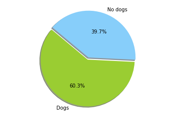

```python
labels = 'Dogs', 'No dogs'
sizes = [DogsCond, 1-DogsCond]
colors = ['yellowgreen', 'lightskyblue']
explode = (0.05, 0)  # explode 1st slice

# Plot
plt.pie(sizes, explode=explode, labels=labels, colors=colors,
        autopct='%1.1f%%', shadow=True, startangle=140)

plt.axis('equal')
plt.show()
```